# Titanic [Exploratory Analysis]

Roman Boimistruk

December 29, 2017

### 1. Loading the data and packages

```r
train <- read.csv("train.csv")
```

### 2. Data Overview

| Variable | Definition | Key | Notes |
| --- | --- | --- | --- |
| PassengerId | PassengerId |  |  |
| Survived | Survival | 1 = Yes, 0 = No |  |
| Pclass | Ticket Class | 1 = 1st, 2 = 2nd, 3 = 3rd | A proxy for socio-economic status (SES) 1st = Upper, 2nd = Middle, 3rd = Lower |
| Name | Name |  |  |
| Sex | Sex |  |  |
| Age | Age |  | Age is fractional if less than 1. If the age is estimated, is it in the form of xx.5 |
| SibSp | # of siblings / spouses aboard |  | Sibling = brother, sister, stepbrother, stepsister, Spouse = husband, wife (mistresses and fiancés were ignored) |
| Parch | # of parents / children aboard |  | Parent = mother, father, Child = daughter, son, stepdaughter, stepson, Some children travelled only with a nanny, therefore parch=0 for them |
| Ticket | Ticket number |  |  |
| Fare | PAssenger fare |  |  |
| Cabin | Cabin number |  |  |
| Embarked | Port of Embarkation | C = Cherbourg, Q = Queenstown, S = Southampton |  |

### 3. Summary of the data

```r
str(train)
```

```
## 'data.frame':    891 obs. of  12 variables:
##  $ PassengerId: int  1 2 3 4 5 6 7 8 9 10 ...
##  $ Survived   : int  0 1 1 1 0 0 0 0 1 1 ...
##  $ Pclass     : int  3 1 3 1 3 3 1 3 3 2 ...
##  $ Name       : Factor w/ 891 levels "Abbing, Mr. Anthony",..: 109 191 358 277 16 559 520 629 417 581 ...
##  $ Sex        : Factor w/ 2 levels "female","male": 2 1 1 1 2 2 2 2 1 1 ...
##  $ Age        : num  22 38 26 35 35 NA 54 2 27 14 ...
##  $ SibSp      : int  1 1 0 1 0 0 0 3 0 1 ...
##  $ Parch      : int  0 0 0 0 0 0 0 1 2 0 ...
##  $ Ticket     : Factor w/ 681 levels "110152","110413",..: 524 597 670 50 473 276 86 396 345 133 ...
##  $ Fare       : num  7.25 71.28 7.92 53.1 8.05 ...
##  $ Cabin      : Factor w/ 148 levels "","A10","A14",..: 1 83 1 57 1 1 131 1 1 1 ...
##  $ Embarked   : Factor w/ 4 levels "","C","Q","S": 4 2 4 4 4 3 4 4 4 2 ...
```

```r
summary(train)
```

```
##   PassengerId       Survived          Pclass
##  Min.   :  1.0   Min.   :0.0000   Min.   :1.000
##  1st Qu.:223.5   1st Qu.:0.0000   1st Qu.:2.000
##  Median :446.0   Median :0.0000   Median :3.000
##  Mean   :446.0   Mean   :0.3838   Mean   :2.309
##  3rd Qu.:668.5   3rd Qu.:1.0000   3rd Qu.:3.000
##  Max.   :891.0   Max.   :1.0000   Max.   :3.000
##
##                                     Name         Sex           Age
##  Abbing, Mr. Anthony                  :  1   female:314   Min.   : 0.42
##  Abbott, Mr. Rossmore Edward          :  1   male  :577   1st Qu.:20.12
##  Abbott, Mrs. Stanton (Rosa Hunt)     :  1                Median :28.00
##  Abelson, Mr. Samuel                  :  1                Mean   :29.70
##  Abelson, Mrs. Samuel (Hannah Wizosky):  1                3rd Qu.:38.00
##  Adahl, Mr. Mauritz Nils Martin       :  1                Max.   :80.00
##  (Other)                              :885                NA's   :177
##      SibSp           Parch             Ticket         Fare
##  Min.   :0.000   Min.   :0.0000   1601    :  7   Min.   :  0.00
##  1st Qu.:0.000   1st Qu.:0.0000   347082  :  7   1st Qu.:  7.91
##  Median :0.000   Median :0.0000   CA. 2343:  7   Median : 14.45
##  Mean   :0.523   Mean   :0.3816   3101295 :  6   Mean   : 32.20
##  3rd Qu.:1.000   3rd Qu.:0.0000   347088  :  6   3rd Qu.: 31.00
##  Max.   :8.000   Max.   :6.0000   CA 2144 :  6   Max.   :512.33
##                                   (Other) :852
##          Cabin     Embarked
##             :687    :  2
##  B96 B98    :  4   C:168
##  C23 C25 C27:  4   Q: 77
##  G6         :  4   S:644
##  C22 C26    :  3
##  D          :  3
##  (Other)    :186
```

```r
head(train)
```

```
##   PassengerId Survived Pclass
## 1           1        0      3
## 2           2        1      1
## 3           3        1      3
## 4           4        1      1
## 5           5        0      3
## 6           6        0      3
##                                                  Name    Sex Age SibSp
## 1                             Braund, Mr. Owen Harris   male  22     1
## 2 Cumings, Mrs. John Bradley (Florence Briggs Thayer) female  38     1
## 3                              Heikkinen, Miss. Laina female  26     0
## 4        Futrelle, Mrs. Jacques Heath (Lily May Peel) female  35     1
## 5                            Allen, Mr. William Henry   male  35     0
## 6                                    Moran, Mr. James   male  NA     0
##   Parch           Ticket    Fare Cabin Embarked
## 1     0        A/5 21171  7.2500              S
## 2     0         PC 17599 71.2833   C85        C
## 3     0 STON/O2. 3101282  7.9250              S
## 4     0           113803 53.1000  C123        S
## 5     0           373450  8.0500              S
## 6     0           330877  8.4583              Q
```

```r
tail(train)
```

```
##     PassengerId Survived Pclass                                     Name
## 886         886        0      3     Rice, Mrs. William (Margaret Norton)
## 887         887        0      2                    Montvila, Rev. Juozas
## 888         888        1      1             Graham, Miss. Margaret Edith
## 889         889        0      3 Johnston, Miss. Catherine Helen "Carrie"
## 890         890        1      1                    Behr, Mr. Karl Howell
## 891         891        0      3                      Dooley, Mr. Patrick
##        Sex Age SibSp Parch     Ticket   Fare Cabin Embarked
## 886 female  39     0     5     382652 29.125              Q
## 887   male  27     0     0     211536 13.000              S
## 888 female  19     0     0     112053 30.000   B42        S
## 889 female  NA     1     2 W./C. 6607 23.450              S
## 890   male  26     0     0     111369 30.000  C148        C
## 891   male  32     0     0     370376  7.750              Q
```

### 4. Exploratory Analysis

Alright, we got an idea about our training dataset. We can see from summary analysis that we hava some NAs (or missing values). Let’s check again with NAs plot using *missmpa function*:

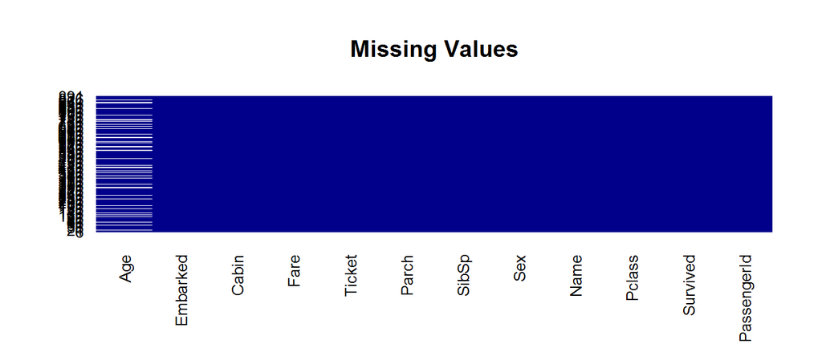

```r
missmap(train, col = c("white","darkblue"), legend = F,  main = "Missing Values")
```

So only Age varibale has some NAs which we should either ignore or replace with the actual values. Embarked and Cabin variables have also some empty values.

Let’s start with the simple stuff and replace Embarked empty values with “S” - the most popular value.

```r
train$Embarked[train$Embarked == ""] <- "S"
```

To fill Age NAs I’m gonna use random forest to predict the Age based on other characteristics

```r
train$Age.old <- train$Age
fit <- train(Age~Survived + Pclass + Sex + Embarked + SibSp + Parch + Fare, data = train[!is.na(train$Age),], method="rf", trControl=trainControl(method="cv", number=10))
new <- cbind(train[is.na(train$Age),], predict(fit, train[is.na(train$Age),]))
train$Age[is.na(train$Age)] <- new[,14]
train$Age <- as.numeric(train$Age)
```

```r
summary(train$Age)
```

```
##    Min. 1st Qu.  Median    Mean 3rd Qu.    Max.
##    0.42   21.05   29.00   29.65   37.00   80.00
```

```r
summary(train$Embarked)
```

```
##       C   Q   S
##   0 168  77 646
```

Now, let’s visualise all variables and highlight Survivals vs. Non-Survivals among each of the characteristics to see if there is any correlation.

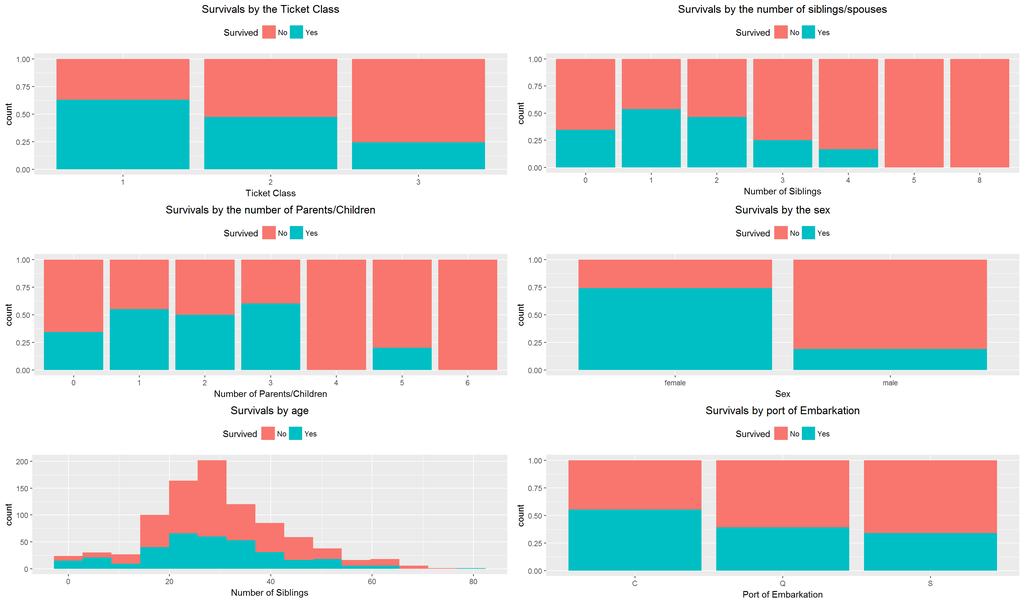

```r
p1 <- ggplot(data = train, aes(as.factor(Pclass), fill = as.factor(Survived))) +
     geom_bar(position = 'fill') +
     labs(x = "Ticket Class") +
     ggtitle("Survivals by the Ticket Class") +
     scale_fill_discrete(name = "Survived",
                         breaks = c(0,1),
                         labels = c("No", "Yes")) +
     theme(legend.position="top", plot.title = element_text(hjust = 0.5))

p2 <- ggplot(data = train, aes(as.factor(SibSp), fill = as.factor(Survived))) +
     geom_bar(position = 'fill') +
     labs(x = "Number of Siblings") +
     ggtitle("Survivals by the number of siblings/spouses") +
     scale_fill_discrete(name = "Survived",
                         breaks = c(0,1),
                         labels = c("No", "Yes")) +
     theme(legend.position="top", plot.title = element_text(hjust = 0.5))

p3 <- ggplot(data = train, aes(as.factor(Parch), fill = as.factor(Survived))) +
     geom_bar(position = 'fill') +
     labs(x = "Number of Parents/Children") +
     ggtitle("Survivals by the number of Parents/Children") +
     scale_fill_discrete(name = "Survived",
                         breaks = c(0,1),
                         labels = c("No", "Yes")) +
     theme(legend.position="top", plot.title = element_text(hjust = 0.5))

p4 <- ggplot(data = train, aes(Sex, fill = as.factor(Survived))) +
     geom_bar(position = 'fill') +
     labs(x = "Sex") +
     ggtitle("Survivals by the sex") +
     scale_fill_discrete(name = "Survived",
                         breaks = c(0,1),
                         labels = c("No", "Yes")) +
     theme(legend.position="top", plot.title = element_text(hjust = 0.5))

p5 <- ggplot(data = train, aes(Age, fill = as.factor(Survived))) +
     geom_histogram(bins = 15) +
     labs(x = "Number of Siblings") +
     ggtitle("Survivals by age") +
     scale_fill_discrete(name = "Survived",
                         breaks = c(0,1),
                         labels = c("No", "Yes")) +
     theme(legend.position="top", plot.title = element_text(hjust = 0.5))

p6 <- ggplot(data = train, aes(Embarked, fill = as.factor(Survived))) +
     geom_bar(position = 'fill') +
     labs(x = "Port of Embarkation") +
     ggtitle("Survivals by port of Embarkation") +
     scale_fill_discrete(name = "Survived",
                         breaks = c(0,1),
                         labels = c("No", "Yes")) +
     theme(legend.position="top", plot.title = element_text(hjust = 0.5))

grid.arrange(p1,p2,p3,p4,p5,p6)
```

From the first glance at the data we can see some clear patterns. For instance, there is strong correlation between **Ticket class**/**Sex** and **Survival rate** - Females were more likely to survive as well as people from the first class.

## 5. Feature Engineering

Let’s see what else can we get from the data.

### 5.1 Titles

```r
head(train$Name)
```

```
## [1] Braund, Mr. Owen Harris
## [2] Cumings, Mrs. John Bradley (Florence Briggs Thayer)
## [3] Heikkinen, Miss. Laina
## [4] Futrelle, Mrs. Jacques Heath (Lily May Peel)
## [5] Allen, Mr. William Henry
## [6] Moran, Mr. James
## 891 Levels: Abbing, Mr. Anthony ... Zimmerman, Mr. Leo
```

```r
tail(train$Name)
```

```
## [1] Rice, Mrs. William (Margaret Norton)
## [2] Montvila, Rev. Juozas
## [3] Graham, Miss. Margaret Edith
## [4] Johnston, Miss. Catherine Helen "Carrie"
## [5] Behr, Mr. Karl Howell
## [6] Dooley, Mr. Patrick
## 891 Levels: Abbing, Mr. Anthony ... Zimmerman, Mr. Leo
```

We can see the pattern that each name includes the passanger title (Mr., Mrs., Master etc.). Let’s extract this infrmation and create a new variable **Title**:

```r
train$Title[grepl("Mr\\.", train$Name, ignore.case = T)] <- "Mr"
train$Title[grepl("Miss\\.|Mlle\\.|Ms\\.|Mme\\.", train$Name, ignore.case = T)] <- "Miss"
train$Title[grepl("Mrs\\.", train$Name, ignore.case = T)] <- "Mrs"
train$Title[grepl("Master\\.", train$Name, ignore.case = T)] <- "Master"
train$Title[grepl("Don\\.", train$Name, ignore.case = T)] <- "Rare"
train$Title[grepl("Rev\\.", train$Name, ignore.case = T)] <- "Rare"
train$Title[grepl("Dr\\.", train$Name, ignore.case = T)] <- "Rare"
train$Title[grepl("Capt\\.", train$Name, ignore.case = T)] <- "Rare"
train$Title[grepl("Col\\.", train$Name, ignore.case = T)] <- "Rare"
train$Title[grepl("Sir\\.", train$Name, ignore.case = T)] <- "Rare"
train$Title[grepl("Major\\.", train$Name, ignore.case = T)] <- "Rare"
train$Title[grepl("Jonkheer\\.", train$Name, ignore.case = T)] <- "Rare"
train$Title[grepl("Countess\\.", train$Name, ignore.case = T)] <- "Rare"
train$Title[grepl("Lady\\.", train$Name, ignore.case = T)] <- "Rare"
train$Title <- as.factor(train$Title)
```

```r
summary(train$Title)
```

```
## Master   Miss     Mr    Mrs   Rare
##     40    186    517    125     23
```

```r
p7 <- ggplot(data = train, aes(as.factor(Title), fill = as.factor(Survived))) +
     geom_bar(position = 'fill') +
     labs(x = "Title") +
     ggtitle("Survivals by the Title") +
     scale_fill_discrete(name = "Survived",
                         breaks = c(0,1),
                         labels = c("No", "Yes")) +
     theme(legend.position="top", plot.title = element_text(hjust = 0.5))
```

### 5.2 Tickets

```r
head(train$Ticket)
```

```
## [1] A/5 21171        PC 17599         STON/O2. 3101282 113803
## [5] 373450           330877
## 681 Levels: 110152 110413 110465 110564 110813 111240 111320 ... WE/P 5735
```

```r
tail(train$Ticket)
```

```
## [1] 382652     211536     112053     W./C. 6607 111369     370376
## 681 Levels: 110152 110413 110465 110564 110813 111240 111320 ... WE/P 5735
```

Each ticket consist of some digits and, in some cases, some letters. Let’s disregards all letters and group all tickets only based om the first digit:

```r
train$Ticket.n[grepl("^1", gsub("[^0-9\\|]", "", train$Ticket))] <- 1
train$Ticket.n[grepl("^2", gsub("[^0-9\\|]", "", train$Ticket))] <- 2
train$Ticket.n[grepl("^3", gsub("[^0-9\\|]", "", train$Ticket))] <- 3
train$Ticket.n[grepl("^4", gsub("[^0-9\\|]", "", train$Ticket))] <- 4
train$Ticket.n[grepl("^5", gsub("[^0-9\\|]", "", train$Ticket))] <- 5
train$Ticket.n[grepl("^6", gsub("[^0-9\\|]", "", train$Ticket))] <- 6
train$Ticket.n[grepl("^7", gsub("[^0-9\\|]", "", train$Ticket))] <- 7
train$Ticket.n[grepl("^8", gsub("[^0-9\\|]", "", train$Ticket))] <- 8
train$Ticket.n[grepl("^9", gsub("[^0-9\\|]", "", train$Ticket))] <- 9
train$Ticket.n[train$Ticket == "LINE"] <- "Line"
train$Ticket.n <- as.factor(train$Ticket.n)
```

```r
summary(train$Ticket.n)
```

```
##    1    2    3    4    5    6    7    8    9 Line
##  227  240  337   20   29   14   15    2    3    4
```

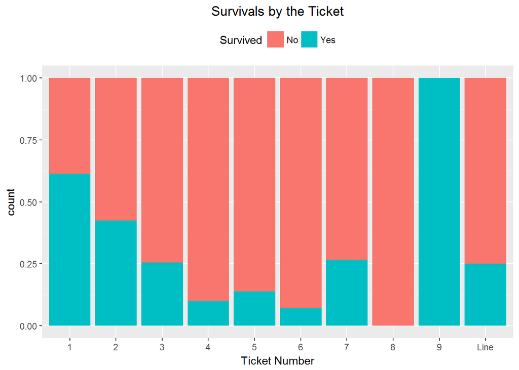

```r
ggplot(data = train, aes(as.factor(Ticket.n), fill = as.factor(Survived))) +
     geom_bar(position = 'fill') +
     labs(x = "Ticket Number") +
     ggtitle("Survivals by the Ticket") +
     scale_fill_discrete(name = "Survived",
                         breaks = c(0,1),
                         labels = c("No", "Yes")) +
     theme(legend.position="top", plot.title = element_text(hjust = 0.5))
```

### 5.3 Age groups - Kids & Adults

We’ve already cleaned Age values so let’s just group them up into categories:

```r
train$Age.n[train$Age < 5] <- "<5"
train$Age.n[train$Age < 10 & train$Age >= 5] <- "5-10"
train$Age.n[train$Age < 20 & train$Age >= 10] <- "10-20"
train$Age.n[train$Age < 25 & train$Age >= 20] <- "20-25"
train$Age.n[train$Age < 28 & train$Age >= 25] <- "25-27"
train$Age.n[train$Age < 30 & train$Age >= 28] <- "28-29"
train$Age.n[train$Age < 33 & train$Age >= 30] <- "30-31"
train$Age.n[train$Age < 35 & train$Age >= 33] <- "32-34"
train$Age.n[train$Age < 40 & train$Age >= 35] <- "35-40"
train$Age.n[train$Age < 50 & train$Age >= 40] <- "40-50"
train$Age.n[train$Age < 100 & train$Age >= 50] <- "50+"
train$Age.n <- as.factor(train$Age.n)
train$Age.n <- factor(train$Age.n, levels = c("<5", "5-10", "10-20", "20-25", "25-27", "28-29", "30-31", "32-34", "35-40", "40-50", "50+"))
```

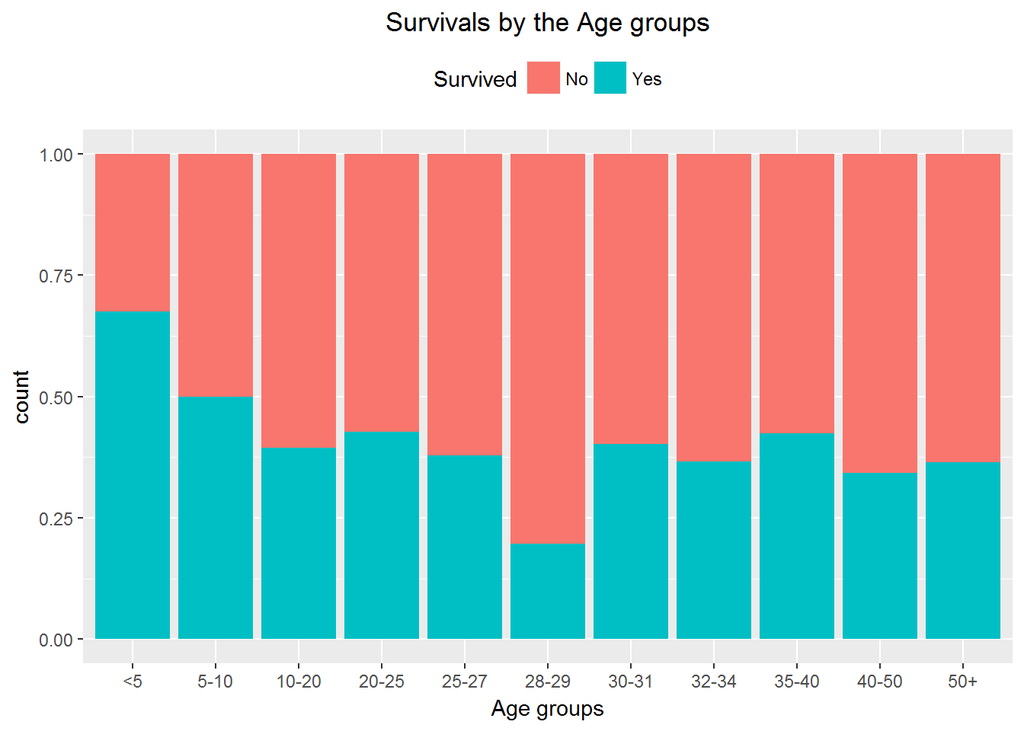

```r
ggplot(data = train, aes(as.factor(Age.n), fill = as.factor(Survived))) +
     geom_bar(position = 'fill') +
     labs(x = "Age groups") +
     ggtitle("Survivals by the Age groups") +
     scale_fill_discrete(name = "Survived",
                         breaks = c(0,1),
                         labels = c("No", "Yes")) +
     theme(legend.position="top", plot.title = element_text(hjust = 0.5))
```

Using the same principles we can create a new column **Kid** for passengers who are yonger than 14.

```r
train$Kid <- "Adult"
train$Kid[train$Age < 14] <- "Kid"
train$Kid <- as.factor(train$Kid)
```

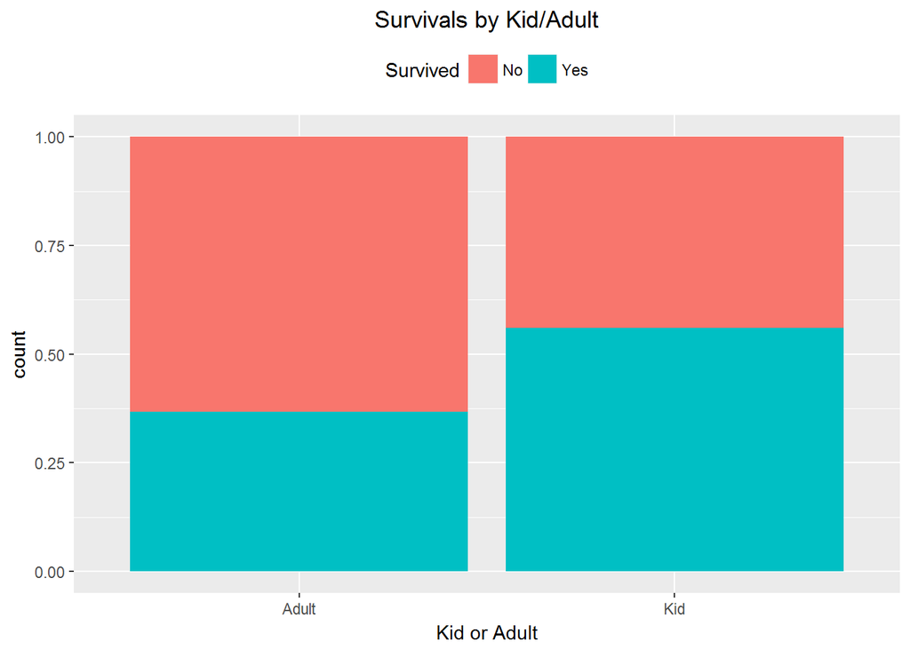

```r
ggplot(data = train, aes(Kid, fill = as.factor(Survived))) +
     geom_bar(position = 'fill') +
     labs(x = "Kid or Adult") +
     ggtitle("Survivals by Kid/Adult") +
     scale_fill_discrete(name = "Survived",
                         breaks = c(0,1),
                         labels = c("No", "Yes")) +
     theme(legend.position="top", plot.title = element_text(hjust = 0.5))
```

### 5.4 Familty Size

Let’s just combined siblings, parents, children and spouses together in the new variable **Family Size**

```r
train$FamilySize <- train$SibSp + train$Parch
train$FamilySize <- as.factor(train$FamilySize)
```

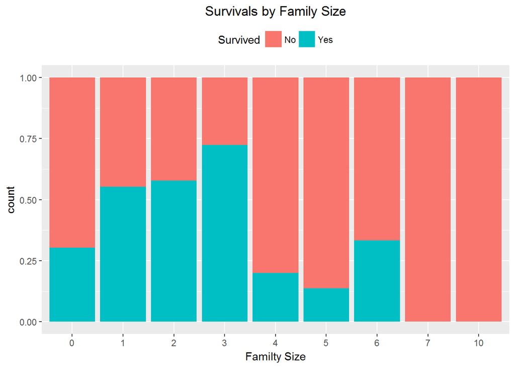

```r
ggplot(data = train, aes(FamilySize, fill = as.factor(Survived))) +
     geom_bar(position = 'fill') +
     labs(x = "Familty Size") +
     ggtitle("Survivals by Family Size") +
     scale_fill_discrete(name = "Survived",
                         breaks = c(0,1),
                         labels = c("No", "Yes")) +
     theme(legend.position="top", plot.title = element_text(hjust = 0.5))
```

## 6. Predictions

Creating validation data set

```r
trainIndex <- createDataPartition(train$Survived, p=0.8, list=FALSE) #Split the data 20/80
data_train <- train[ trainIndex,]
data_val <- train[-trainIndex,]
```

Assigning Control and Metic characteristics. I will use 10-fold Cross Validation and we want our model to show us its Accuracy and Kappa.

```r
control <- trainControl(method="cv", number=10)
metric <- "Accuracy"
```

### 6.1. Linear Discriminant Analysis

```r
set.seed(7)
fit.lda <- train(as.factor(Survived)~Pclass+Title+Age+Fare, data = data_train, method="lda", metric=metric, trControl=control)
fit.lda
```

```
## Linear Discriminant Analysis
##
## 713 samples
##   4 predictor
##   2 classes: '0', '1'
##
## No pre-processing
## Resampling: Cross-Validated (10 fold)
## Summary of sample sizes: 641, 642, 641, 642, 642, 642, ...
## Resampling results:
##
##   Accuracy   Kappa
##   0.8008216  0.5751378
```

### 6.2. Classification and Regression Trees

```r
set.seed(7)
fit.cart <- train(as.factor(Survived)~Pclass+Title+Age+Fare, data = data_train, method="rpart", metric=metric, trControl=control)
fit.cart
```

```
## CART
##
## 713 samples
##   4 predictor
##   2 classes: '0', '1'
##
## No pre-processing
## Resampling: Cross-Validated (10 fold)
## Summary of sample sizes: 641, 642, 641, 642, 642, 642, ...
## Resampling results across tuning parameters:
##
##   cp          Accuracy   Kappa
##   0.02962963  0.8260563  0.6268880
##   0.05000000  0.8078052  0.5958655
##   0.46666667  0.6887128  0.2445689
##
## Accuracy was used to select the optimal model using the largest value.
## The final value used for the model was cp = 0.02962963.
```

### 6.3. k-Nearest Neighbors

```r
set.seed(7)
fit.knn <- train(as.factor(Survived)~Pclass+Title+Age+Fare, data = data_train, method="knn", metric=metric, trControl=control)
fit.knn
```

```
## k-Nearest Neighbors
##
## 713 samples
##   4 predictor
##   2 classes: '0', '1'
##
## No pre-processing
## Resampling: Cross-Validated (10 fold)
## Summary of sample sizes: 641, 642, 641, 642, 642, 642, ...
## Resampling results across tuning parameters:
##
##   k  Accuracy   Kappa
##   5  0.7137911  0.3757641
##   7  0.7236894  0.3944528
##   9  0.7207942  0.3788840
##
## Accuracy was used to select the optimal model using the largest value.
## The final value used for the model was k = 7.
```

### 6.4. Support Vector Machines (SVM)

```r
set.seed(7)
fit.svm <- train(as.factor(Survived)~Pclass+Title+Age+Fare, data = data_train, method="svmRadial", metric=metric, trControl=control)
fit.svm
```

```
## Support Vector Machines with Radial Basis Function Kernel
##
## 713 samples
##   4 predictor
##   2 classes: '0', '1'
##
## No pre-processing
## Resampling: Cross-Validated (10 fold)
## Summary of sample sizes: 641, 642, 641, 642, 642, 642, ...
## Resampling results across tuning parameters:
##
##   C     Accuracy   Kappa
##   0.25  0.8274257  0.6301686
##   0.50  0.8386346  0.6523160
##   1.00  0.8372261  0.6521383
##
## Tuning parameter 'sigma' was held constant at a value of 1.300779
## Accuracy was used to select the optimal model using the largest value.
## The final values used for the model were sigma = 1.300779 and C = 0.5.
```

### 6.5. Random Forest

```r
set.seed(7)
fit.rf <- train(as.factor(Survived)~Pclass+Title+Age+Fare, data = data_train, method="rf", metric=metric, trControl=control)
fit.rf
```

```
## Random Forest
##
## 713 samples
##   4 predictor
##   2 classes: '0', '1'
##
## No pre-processing
## Resampling: Cross-Validated (10 fold)
## Summary of sample sizes: 641, 642, 641, 642, 642, 642, ...
## Resampling results across tuning parameters:
##
##   mtry  Accuracy   Kappa
##   2     0.8401408  0.6552860
##   4     0.8442684  0.6614682
##   7     0.8148279  0.6035504
##
## Accuracy was used to select the optimal model using the largest value.
## The final value used for the model was mtry = 4.
```

### 6.6. Logistics Regression

```r
set.seed(7)
fit.glm <- train(as.factor(Survived)~Pclass+Title+Age+Fare, data = data_train, method="glm", metric=metric, trControl=control)
fit.glm
```

```
## Generalized Linear Model
##
## 713 samples
##   4 predictor
##   2 classes: '0', '1'
##
## No pre-processing
## Resampling: Cross-Validated (10 fold)
## Summary of sample sizes: 641, 642, 641, 642, 642, 642, ...
## Resampling results:
##
##   Accuracy  Kappa
##   0.797946  0.567383
```

### 6.7 Results

Let’s look at the results of all our models and plot the graph with Accuracy/Kappa.

```r
results <- resamples(list(lda=fit.lda, cart=fit.cart, knn=fit.knn, svm=fit.svm, rf=fit.rf, glm = fit.glm))
summary(results)
```

```
##
## Call:
## summary.resamples(object = results)
##
## Models: lda, cart, knn, svm, rf, glm
## Number of resamples: 10
##
## Accuracy
##           Min.   1st Qu.    Median      Mean   3rd Qu.      Max. NA's
## lda  0.7042254 0.7561620 0.8111307 0.8008216 0.8466843 0.8732394    0
## cart 0.7183099 0.8175372 0.8392019 0.8260563 0.8466843 0.9014085    0
## knn  0.6056338 0.6864730 0.7112676 0.7236894 0.7429577 0.8611111    0
## svm  0.7323944 0.8345070 0.8461463 0.8386346 0.8680556 0.9154930    0
## rf   0.7183099 0.8315728 0.8530908 0.8442684 0.8745599 0.9154930    0
## glm  0.7042254 0.7613948 0.8169014 0.7979460 0.8421362 0.8732394    0
##
## Kappa
##           Min.   1st Qu.    Median      Mean   3rd Qu.      Max. NA's
## lda  0.3393886 0.4953078 0.6024191 0.5751378 0.6697528 0.7403495    0
## cart 0.3847487 0.6181591 0.6515919 0.6268880 0.6731340 0.7923109    0
## knn  0.1632997 0.3040779 0.3669706 0.3944528 0.4203888 0.6992481    0
## svm  0.4111742 0.6438229 0.6702847 0.6523160 0.7138624 0.8181042    0
## rf   0.3847487 0.6315339 0.6886676 0.6614682 0.7246747 0.8181042    0
## glm  0.3393886 0.5038202 0.6156424 0.5673830 0.6621081 0.7291225    0
```

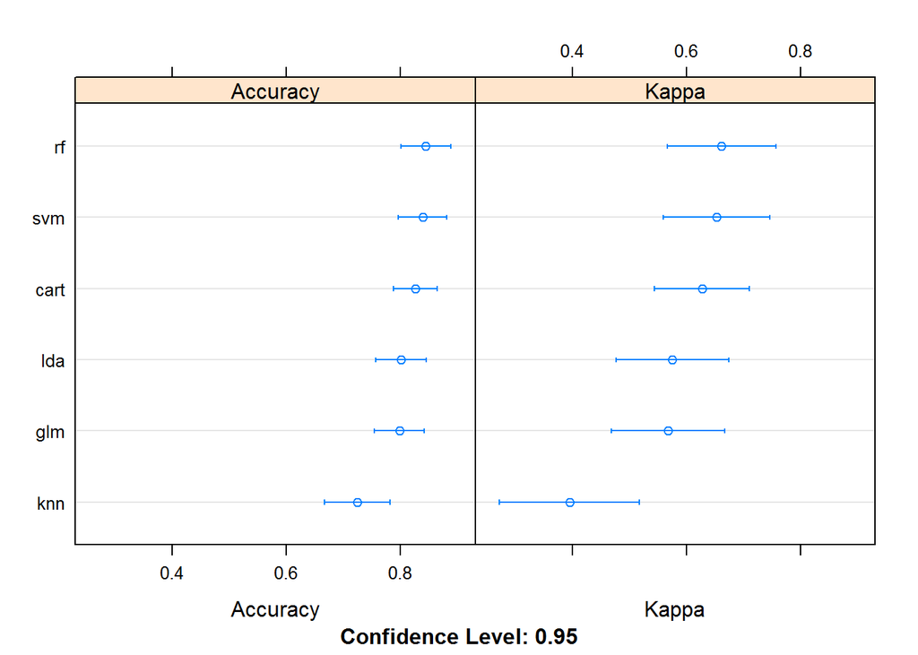

```r
dotplot(results)
```

Ploting confusion matrix on the Random Forest and SVM models

```r
confusionMatrix(predict(fit.rf, data_val), data_val$Survived)
```

```
## Confusion Matrix and Statistics
##
##           Reference
## Prediction  0  1
##          0 95 19
##          1 11 53
##
##                Accuracy : 0.8315
##                  95% CI : (0.7682, 0.8833)
##     No Information Rate : 0.5955
##     P-Value [Acc > NIR] : 1.009e-11
##
##                   Kappa : 0.6438
##  Mcnemar's Test P-Value : 0.2012
##
##             Sensitivity : 0.8962
##             Specificity : 0.7361
##          Pos Pred Value : 0.8333
##          Neg Pred Value : 0.8281
##              Prevalence : 0.5955
##          Detection Rate : 0.5337
##    Detection Prevalence : 0.6404
##       Balanced Accuracy : 0.8162
##
##        'Positive' Class : 0
##
```

```r
confusionMatrix(predict(fit.svm, data_val), data_val$Survived)
```

```
## Confusion Matrix and Statistics
##
##           Reference
## Prediction  0  1
##          0 91 25
##          1 15 47
##
##                Accuracy : 0.7753
##                  95% CI : (0.7068, 0.8343)
##     No Information Rate : 0.5955
##     P-Value [Acc > NIR] : 3.065e-07
##
##                   Kappa : 0.5229
##  Mcnemar's Test P-Value : 0.1547
##
##             Sensitivity : 0.8585
##             Specificity : 0.6528
##          Pos Pred Value : 0.7845
##          Neg Pred Value : 0.7581
##              Prevalence : 0.5955
##          Detection Rate : 0.5112
##    Detection Prevalence : 0.6517
##       Balanced Accuracy : 0.7556
##
##        'Positive' Class : 0
##
```

As we can see Random Forest has higher Accuracy. So lets try our model to the test set. BNut before this I’m gonna apply all the changes to the test data set that I applied to training (another option is to combine both data sets together and identify them by the new variable).

```r
test <- read.csv("test.csv")
```

Now I’m gonna use Random Forest model to fit on test data set to predict Survivals:

```r
fit.rf <- train(as.factor(Survived)~as.factor(Pclass)+Title+Age+Fare, data = train, method="rf", metric=metric, trControl=control)
predictions <- predict(fit.rf, test)
x <- cbind(test$PassengerId, as.data.frame(predictions))
colnames(x) <- c("PassengerID", "Survived")
write.csv(x, "test.csv", row.names = F)
```

We got **75.12%** after submitting on kaggle.